# Part II - Programme for International Student Assessment (PISA) investigation

## Investigation Overview

In this presentation we attempt to answer the following questions :

- How does the choice of school play into academic performance?
- Are there differences in achievement based on gender, location, or student attitudes?
- Are there differences in achievement based on teacher practices and attitudes?
- Does there exist inequality in academic achievement?

In that line, we have hinted the following features to help in our investigation : School climate indices and Attitudes towards school could help investigate how choice of school impact academic performance. Education level of parents, family structure, relative grade, household possessions, attitudes towards mathematics and opportunity to learn could help understand the differences in achievement whether based on gender, location, student attitudes or teacher practices and attitudes. Finally Highest occupational status of parents and immigration background could highlight the existence of inequality in academic achievement.

## PISA 2012 Dataset Overview

PISA is a is a survey of students' skills and knowledge as they approach the end of compulsory education. The dataset is is a worldwide study developed by the Organisation for Economic Co-operation and Development (OECD) which examines the skills of 15-year-old school students around the world. The study assesses students’ mathematics, science, and reading skills and contains a wealth of information on students’ background, their school and the organisation of education systems.

## how should parents equip their home?

> From the summary of possession distribution, parents are clearly undecided in posessing more or less Literature, poetry, art, technical reference book, software at home. On the other side, there is a predominance of desk, own room, study place, computer, internet, dictionary, dishwasher, DVD at home.

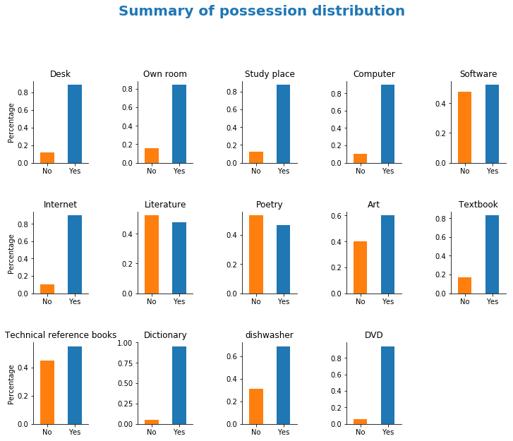

## Shall we live with relatives at home ?

> Mother and Father are the parents that are majorly at home while Grandparents and Others are not so often in the lives of the students.

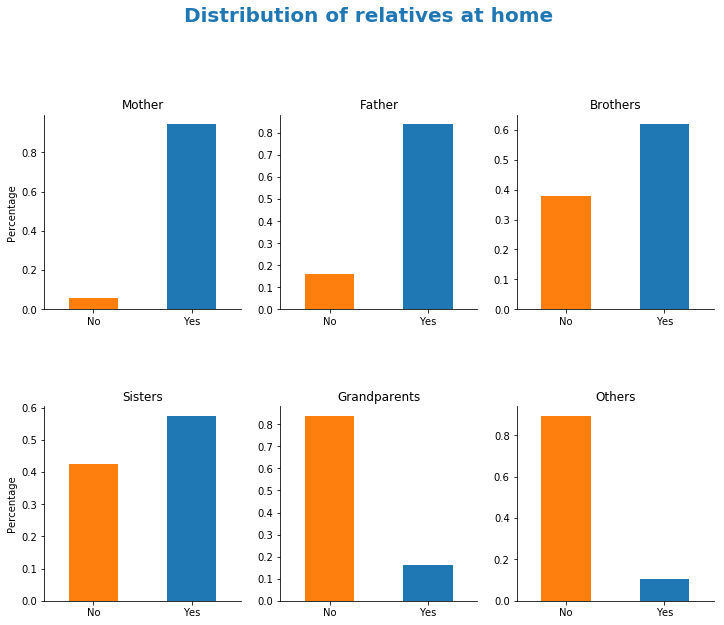

## Mummy, i need you around

The relative grade index (GRADE) was computed to capture between country variation. It indicates whether students are at a modal grade in a country (value of 0) or whether they are below or above the modal grade (+x grades, -x grades).

65% of students need their mum at home.

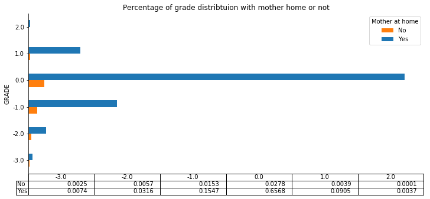

## Daddy so do you

59% of students needs their dads at home.

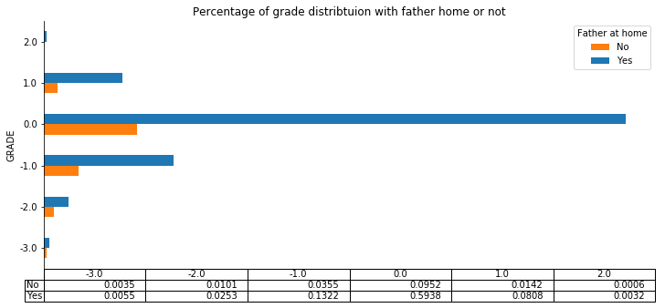

## Because i know, i perform

When students are aware of the learning activities they perform well.

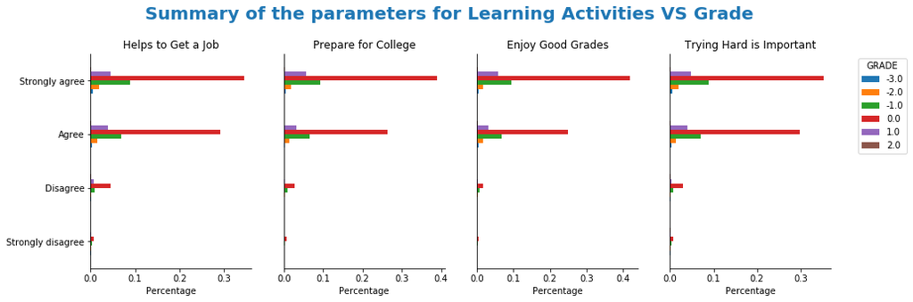

## And I have some routines in mathematics

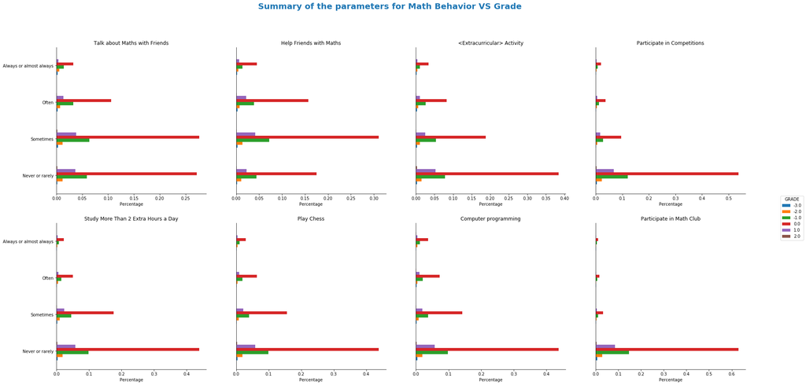

## And my instructor helps me

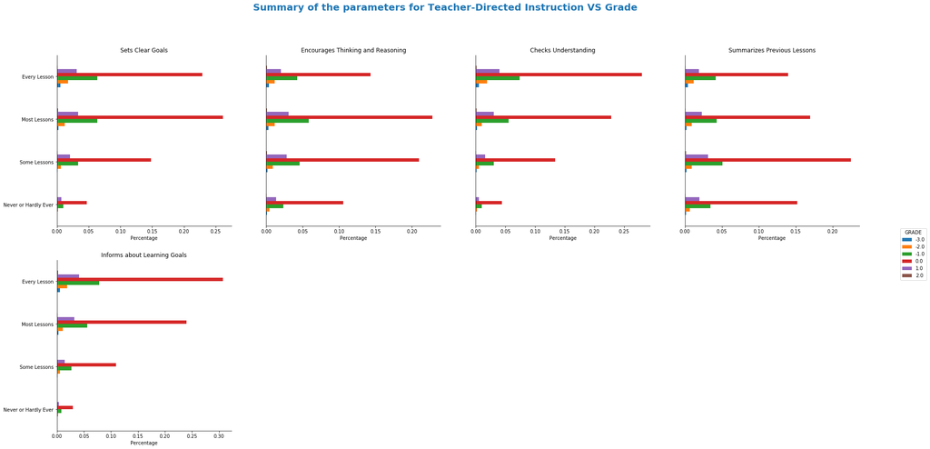

## So be sure i have all i need regardless of my gender

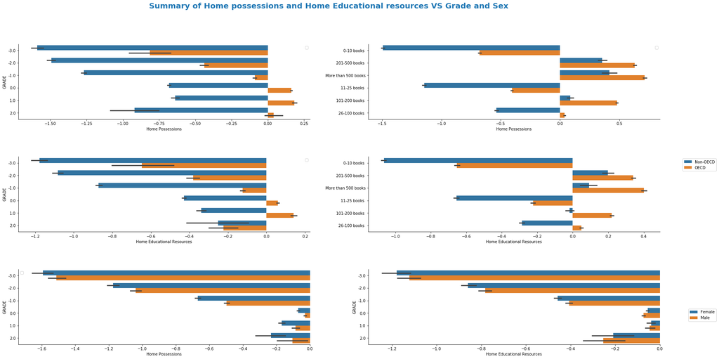

> Students oecd countries play a role in their grade.

> Performance in mathematics is not gender based

Finally, the family wealth of students who are in OECD countries contribute to their mathematics performance as opposed to those who are in non OECD countries.